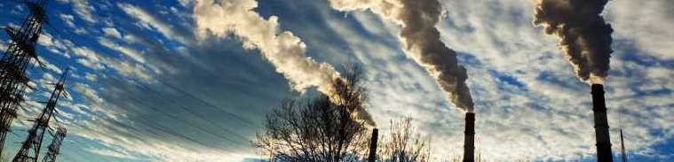

### Air Pollution pm2.5 - 2004 to 2013

Hossein Parsa

#### Introduction

Air pollution is a combination of gases, liquids, and particulate matter that increase the risk of cardiovascular events. [Particulate matter](http://www.epa.gov/airscience/air-particulatematter.htm) (PM) is an air pollution term for a mixture of solid particles and liquid droplets found in the air. The pollutant comes in a variety of sizes and can be composed of many types of materials and chemicals. Particles that are small enough to be inhaled have the potential to cause health effects. Of particular concern is a class of particles known as fine particulate matter or PM2.5 that gets deep into the lung. The relative size these particles is shown in figure 1.

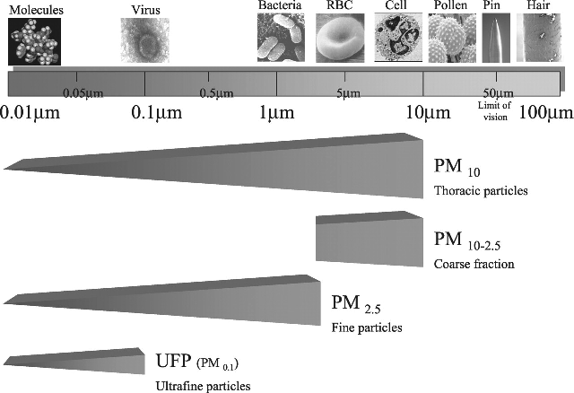

[figure 1](http://circ.ahajournals.org/content/109/21/2655/F1.expansion.html): Particulate matter air pollution size distribution.

There are many sources of PM. The air pollutant can originate from natural processes, like forest fires and wind erosion, and from human activities, like agricultural practices, smokestacks, car emissions, and construction. Examples include dust, dirt, soot, soil, and smoke. One of the important pieces of legislation in the last four decades in the United States has been the Clean Air Act. The Clean Air Act has been designed to reduce the levels of air pollution in the United States. And fine particle air pollution was started being measured since 1999.

In particular we’re looking at fine particulate matter air pollution or pm that is in the air. This is a health concern since we inhale the air and along with that, the particulate matter or dust will be inhaled as well.

So the first question that might be asked is, are air pollution levels lower now than they were before? We’re going to approach answering this question by looking at a fine particle air pollution that was started being measured by Environmental Protection Agency, EPA, since 1999; we look at a 10 year trend of pm2.5 values. And also answering the question, Are the levels on average lower in 2013 than they were in 2004?

#### Getting data

In this data exploration we look at the data that comes from the U.S. EPA and it involves air pollution monitoring data from all the states in the United States. Air pollution data in the United States is collected by EPA and is made freely available on their website based on FOIA. So we start by collection data from EPA website. We will be looking at 10 years, the data of which are available in 10 different zip files. Since the files have different names we will not be able to read the data in a loop so we’ll be having separate code for each year. In the following piece of R code we first download the files[^1] from 2004 to 2013 and then read and clean the data. For cleaning the data we use `stringi` package. Some of the data cleaning involves correcting state codes that are in numeric format (missing leading zero for some states) in recent years and match that data with previous formatting.

```r
temp <- tempfile()
download.file("http://www.epa.gov/ttn/airs/airsaqs/detaildata/501files/Rd_501_88101_2004.Zip",temp)
pm04 <- read.table(unz(temp, "RD_501_88101_2004-0.txt"), comment.char = "#", header = F, sep = "|", na.string="")
cnames <- readLines(unz(temp, "RD_501_88101_2004-0.txt"), 1)
names(pm04) <- make.names(strsplit(cnames, "|", fixed = T)[[1]])
unlink(temp)
```

#### Comparision of summaries by year

Now that the data are available in table format we will take a look at summary of pm measured indicated by sample values in the files. We `rbind` the summary of each year to compare the different years.

```r
for (i in 4:13){y<-stri_pad_left(i, 2, "0");eval(parse(text=paste("y", y, " <- pm", y, "$Sample.Value", sep="")))}

summary10<-summary(y04)
for (i in 5:13){y<-stri_pad_left(i, 2, "0");eval(parse(text=paste("summary10 <- rbind(summary10, summary(y", y, "))", sep="")))}
```

```
##      Min. 1st Qu. Median   Mean 3rd Qu.  Max.   NA's
## 2004    0   6.500   10.0 11.910    15.2 505.6   9123
## 2005    0   6.800   10.7 12.720    16.4 132.6  10177
## 2006    0   6.400    9.9 11.620    15.0 193.0   8954
## 2007    0   6.400   10.1 12.070    15.6 172.3   9851
## 2008  -10   5.533    9.0 11.210    14.5 985.0  15124
## 2009  -10   4.600    8.0 10.300    13.4 985.2  45540
## 2010  -10   4.700    8.1 10.420    14.0 886.5  99964
## 2011  -10   4.300    8.0 10.040    13.0 996.9 180268
## 2012  -10   4.000    7.8  9.429    12.2 985.0 176732
## 2013  -10   4.000    7.2  9.464    12.0 985.0 177267
```

In the 2004 data, the median is about 10.0 and mean 11.9. Considering the summary of 2013 data, it seems that the values are decreasing in the entire country. The plots below also show the same trend. But what we also notice is that the negative values have appeared in the data sets since 2008. negative values basically cannot be correct because pm is the measure of mass which cannot be negative. Also in the same year max values jumped high abnormally. This can be due to errors in monitoring devices. The graphs below show the rend of median, mean, max and proportion of NA data throughout the years. For these plots `ggplot2` and `gridExtra` package has been used.

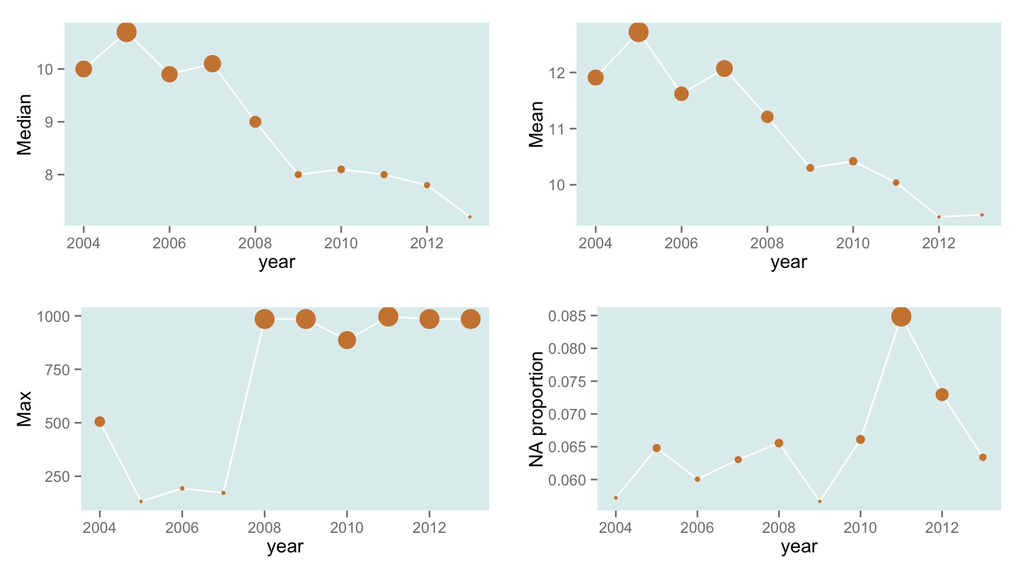

```r
library(ggplot2)
medp<-ggplot(dfsummary, aes(year, Median))+geom_line(colour="white")+geom_point(aes(size=Median), colour="tan3") +theme(panel.grid.minor = element_blank(), panel.grid.major = element_blank(), panel.background = element_rect(fill = "azure2"),  legend.position = "none")+ylab("Median")

meanp<-ggplot(dfsummary, aes(year, Mean))+geom_line(colour="white")+geom_point(aes(size=Mean), colour="tan3") +theme(panel.grid.minor = element_blank(), panel.grid.major = element_blank(), panel.background = element_rect(fill = "azure2"),  legend.position = "none")+ylab("Mean")

maxp<-ggplot(dfsummary, aes(year, Max.))+geom_line(colour="white")+geom_point(aes(size=Max.), colour="tan3") +theme(panel.grid.minor = element_blank(), panel.grid.major = element_blank(), panel.background = element_rect(fill = "azure2"),  legend.position = "none")+ylab("Max")

dfsummary$na.prop=c(mean(is.na(y04)), mean(is.na(y05)), mean(is.na(y06)), mean(is.na(y07)), mean(is.na(y08)), mean(is.na(y09)), mean(is.na(y10)), mean(is.na(y11)), mean(is.na(y12)), mean(is.na(y13)))

nap<-ggplot(dfsummary, aes(year, na.prop))+geom_line(colour="white")+geom_point(aes(size=na.prop), colour="tan3") +theme(panel.grid.minor = element_blank(), panel.grid.major = element_blank(), panel.background = element_rect(fill = "azure2"),  legend.position = "none")+ylab("NA proportion")

library(gridExtra)
grid.newpage()
pushViewport(viewport(layout=grid.layout(2,2)))
print(medp, vp=viewport(layout.pos.row=1, layout.pos.col=1))
print(meanp, vp=viewport(layout.pos.row=1, layout.pos.col=2))
print(maxp, vp=viewport(layout.pos.row=2, layout.pos.col=1))
print(nap, vp=viewport(layout.pos.row=2, layout.pos.col=2))
```

To compare how the data is spread across the ranges we’ll take a look at boxplot of sample values. To fix the right skewness of data however, we will be plotting the log of the values.

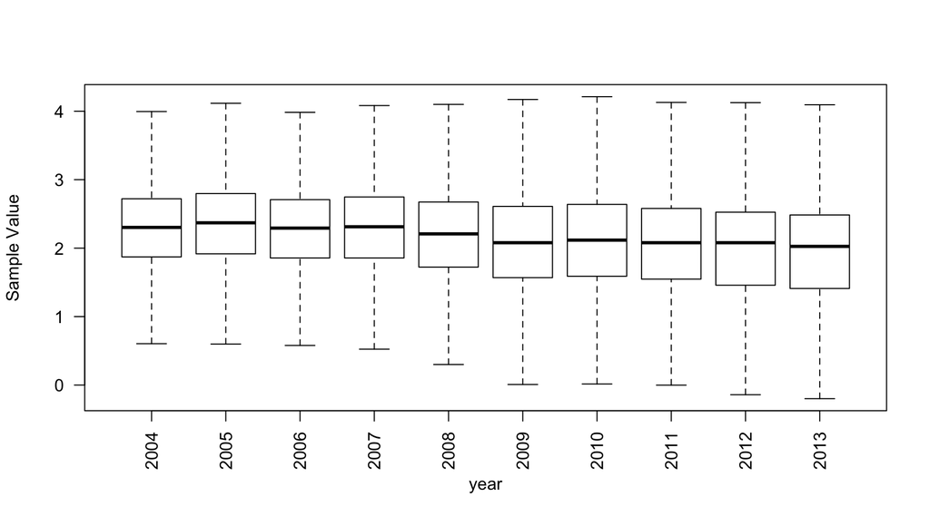

```r
par(las = 2)
boxplot(log(y04), log(y05), log(y06), log(y07), log(y08), log(y09), log(y10), log(y11), log(y12), log(y13), names=c(2004:2013), ylab="Sample Value", xlab="year", outline = F)
```

#### Air pollution in states

Now we look at the data for each state and try to find out the trend of means over the years. In the plots, below all the states have been plotted into 4 equally populated groups just to be easily seen. So each color shows the mean value of pm measured for each state from 2004 to 2013. As depicted, values for the most part are decreasing from the past toward now.

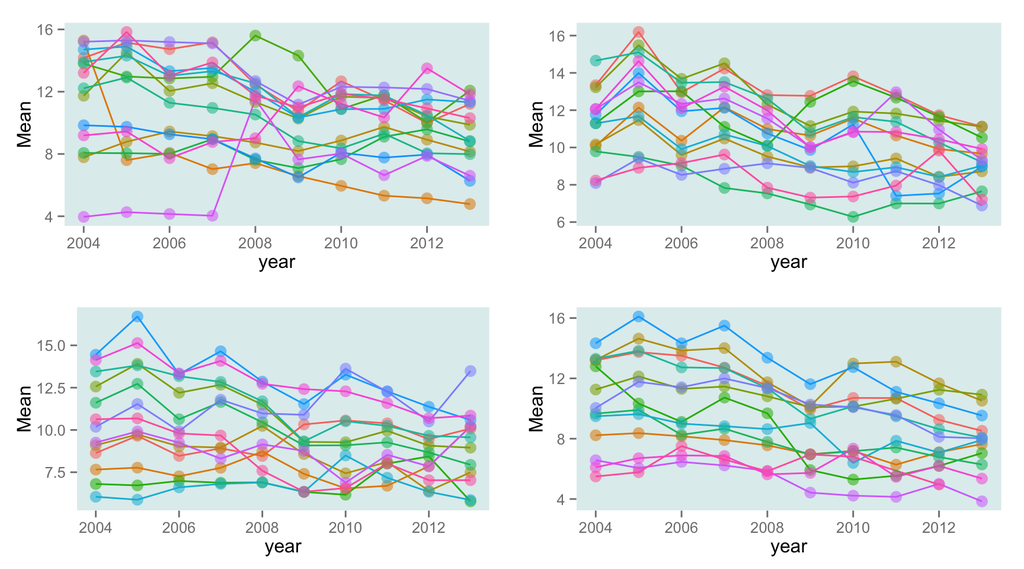

```r
for (i in 4:13) {
  y<-stri_pad_left(i, 2, "0")
  eval(parse(text=paste("mn_st", y, " <- with(pm", y, ", tapply(Sample.Value, State.Code, mean, na.rm = T))", sep="")))
  eval(parse(text=paste("df_mn_st", y," <- data.frame(year=20", y,", state = names(mn_st", y,"), mean = mn_st", y,")", sep="")))
  }
bd <- df_mn_st04

for (i in 5:13) {
  y<-stri_pad_left(i, 2, "0")
  eval(parse(text=paste("bd <- rbind(bd, df_mn_st", y,")", sep="")))
}
bd<-subset(bd, bd$state !="CC")
q1<-quantile(as.numeric(bd$state), .25)
q2<-quantile(as.numeric(bd$state), .5)
q3<-quantile(as.numeric(bd$state), .75)
q4<-quantile(as.numeric(bd$state), 1)

qp1<-ggplot(subset(bd, as.numeric(state)>0 & as.numeric(state)<=q1 ), aes(year, mean, color=state))+geom_line()+geom_point(aes(size=2, alpha=.3)) +theme(panel.grid.minor = element_blank(), panel.grid.major = element_blank(), panel.background = element_rect(fill = "azure2"),  legend.position = "none")+ylab("Mean")

qp2<-ggplot(subset(bd, as.numeric(state)>q1 & as.numeric(state)<=q2 ), aes(year, mean, color=state))+geom_line()+geom_point(aes(size=2, alpha=.3)) +theme(panel.grid.minor = element_blank(), panel.grid.major = element_blank(), panel.background = element_rect(fill = "azure2"),  legend.position = "none")+ylab("Mean")

qp3<-ggplot(subset(bd, as.numeric(state)>q2 & as.numeric(state)<=q3 ), aes(year, mean, color=state))+geom_line()+geom_point(aes(size=2, alpha=.3)) +theme(panel.grid.minor = element_blank(), panel.grid.major = element_blank(), panel.background = element_rect(fill = "azure2"),  legend.position = "none")+ylab("Mean")

qp4<-ggplot(subset(bd, as.numeric(state)>q3 & as.numeric(state)<=q4 ), aes(year, mean, color=state))+geom_line()+geom_point(aes(size=2, alpha=.3)) +theme(panel.grid.minor = element_blank(), panel.grid.major = element_blank(), panel.background = element_rect(fill = "azure2"),  legend.position = "none")+ylab("Mean")

grid.newpage()
pushViewport(viewport(layout=grid.layout(2,2)))
print(qp1, vp=viewport(layout.pos.row=1, layout.pos.col=1))
print(qp2, vp=viewport(layout.pos.row=1, layout.pos.col=2))
print(qp3, vp=viewport(layout.pos.row=2, layout.pos.col=1))
print(qp4, vp=viewport(layout.pos.row=2, layout.pos.col=2))
```

One way of looking at this data is to ignore the years and see how wide spread is the data for each state collectively throughout the years. In fact longer box for each state represents more fluctuation in the previous graph for that state.

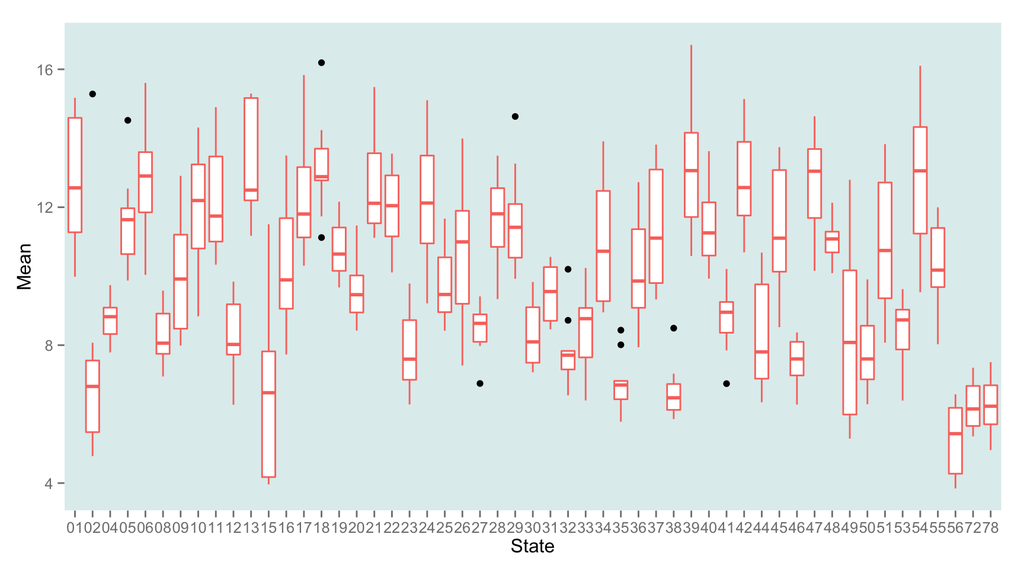

[State code](http://www.epa.gov/envirofw/html/codes/state.html) mapping is as follows:

```r
dfst<-data.frame(read.table("state_codes_FIPS.csv", header = T, sep = ",", na.string="", colClasses=c("character")))
sort(paste(dfst$Code, dfst$Name, sep=":"))
```

```
"01:ALABAMA"              "02:ALASKA"               "04:ARIZONA"              "05:ARKANSAS"
"06:CALIFORNIA"           "08:COLORADO"             "09:CONNECTICUT"          "10:DELAWARE"
"11:DISTRICT OF COLUMBIA" "12:FLORIDA"              "13:GEORGIA"              "15:HAWAII"
"16:IDAHO"                "17:ILLINOIS"             "18:INDIANA"              "19:IOWA"
"20:KANSAS"               "21:KENTUCKY"             "22:LOUISIANA"            "23:MAINE"
"24:MARYLAND"             "25:MASSACHUSETTS"        "26:MICHIGAN"             "27:MINNESOTA"
"28:MISSISSIPPI"          "29:MISSOURI"             "30:MONTANA"              "31:NEBRASKA"
"32:NEVADA"               "33:NEW HAMPSHIRE"        "34:NEW JERSEY"           "35:NEW MEXICO"
"36:NEW YORK"             "37:NORTH CAROLINA"       "38:NORTH DAKOTA"         "39:OHIO"
"40:OKLAHOMA"             "41:OREGON"               "42:PENNSYLVANIA"         "44:RHODE ISLAND"
"45:SOUTH CAROLINA"       "46:SOUTH DAKOTA"         "47:TENNESSEE"            "48:TEXAS"
"49:UTAH"                 "50:VERMONT"              "51:VIRGINIA"             "53:WASHINGTON"
"54:WEST VIRGINIA"        "55:WISCONSIN"            "56:WYOMING"              "60:AMERICAN SAMOA"
"66:GUAM"                 "72:PUERTO RICO"          "78:VIRGIN ISLANDS"
```

#### Overal trend

Now going back to yearly trends, the following barchart shows the distribution of mean of states in different years. It is interesting that how the distribution is getting centralized and less spread while moving toward smaller values of mean. This is most probably caused by implementation of similar approaches to clean air in different states.

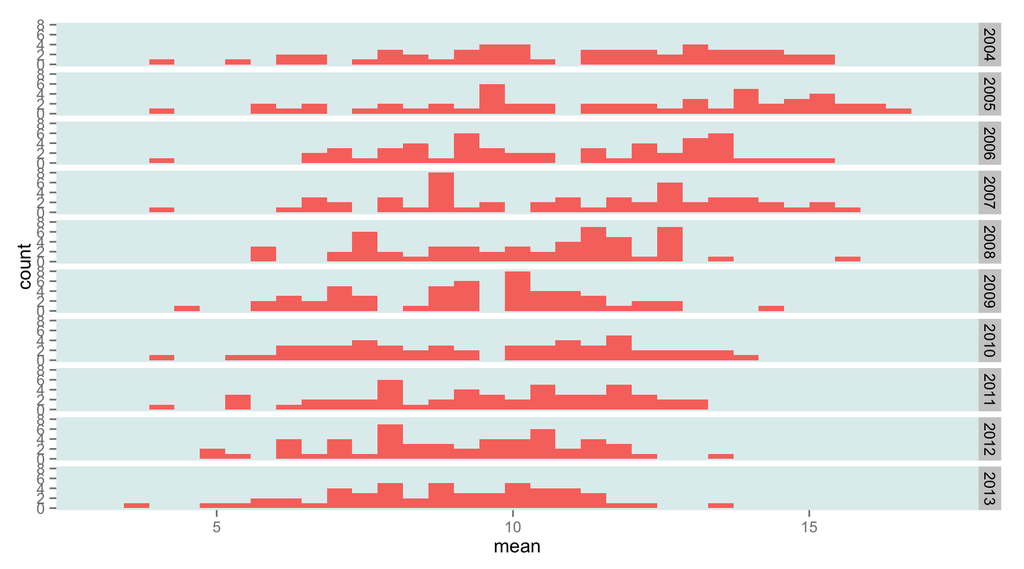

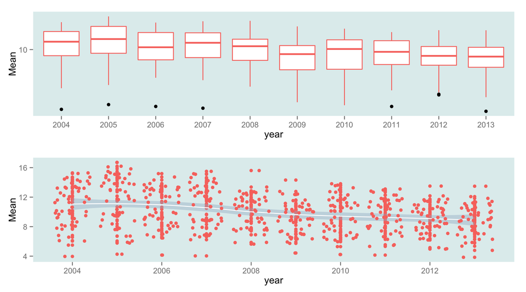

And finally a quick regression of mean on year can show how much the mean of sample values have been decreasing and is expected to decrease each year.

```
##
## Call:
## lm(formula = mean ~ year, data = bd)
##
## Residuals:
##     Min      1Q  Median      3Q     Max
## -7.3116 -1.7419  0.2076  2.0154  5.7122
##
## Coefficients:
##              Estimate Std. Error t value Pr(>|t|)
## (Intercept) 570.09554   75.79960   7.521 2.36e-13 ***
## year         -0.27885    0.03774  -7.389 5.85e-13 ***
## ---
## Signif. codes:  0 '***' 0.001 '**' 0.01 '*' 0.05 '.' 0.1 ' ' 1
##
## Residual standard error: 2.488 on 526 degrees of freedom
## Multiple R-squared:  0.09403,    Adjusted R-squared:  0.09231
## F-statistic:  54.6 on 1 and 526 DF,  p-value: 5.854e-13
```

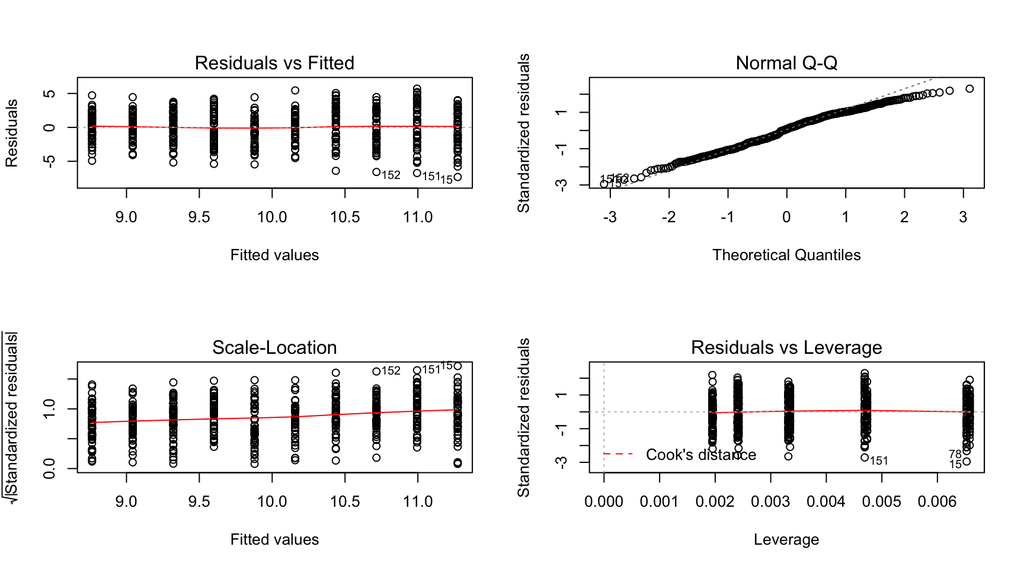

To summarize the basic question, we were trying to find out if particular matter levels have decreased from 2004 to 2013 and how the trends look like. We first looked at the data for the entire country and then we tried to explore the trend for individual states. Through a combination of data summaries and plots, we could get an exploratory view at the data and see what kind of other questions we can continue to ask.

[^1]: Air Quality System or AQS data is available at [EPA](http://www.epa.gov/ttn/airs/airsaqs/detaildata/downloadaqsdata.htm).